# Tarea 1 - IN5162, Semestre Primavera 2025

Lamich, Muñoz, Venegas.

03 septiembre, 2025

## Preliminares

(0.0 puntos) Escriban acá todos los comandos que necesita ejecutar antes de abordar las preguntas de la tarea (carga de librerías, lectura de datos, limpieza de la data, transformación de variables y todo lo que necesite).

#### Preparación Tarea

```r
#Exploración de datos
library(readxl)
library(fixest)
library(ggplot2)
library(dplyr)
library(knitr)
library(glmnet)
library(kableExtra)
library(modelsummary)
library(caret)
library(earth)
library(randomForest)
library(tidyr)
rm(list=ls())         # Limpia la lista de objetos
graphics.off()        # Limpia la lista de gráficos
options(digits = 5)   # Número de dígitos a utilizar
```

```r
#setwd("C:\Users\Leandro\Documents\github\Uni\Ingenieria de marketing")  # fijando el directorio de trabajo
```

```r
#Exploración de datos
# Leemos el archivo xlsx de Canasta de productos.
datos_precios = read_excel("Canasta_de_productos.xlsx")

# Cargamos la base tipo de cambio.
Tipo_cambio <- read.csv("Tipo_cambio.csv")

# Cargamos la base de variables macros utilizadas.
macro <- read.csv("variables_macro.csv")

#Mostramos las bases.
head(datos_precios)
```

| Ano | Mes | Categoria | Sub-categoria | Producto | Pais | Cadena | Marca | Marca_propia | Peso_Volumen | Promocion | Precio_Normal | Precio_Oferta |
| --- | --- | --- | --- | --- | --- | --- | --- | --- | --- | --- | --- | --- |
| 2021 | Diciembre | Aguas | Agua mineral | Agua con gas | Argentina | Carrefour | Carrefour | 1 | 2.00 | 1 | 52.00 | 46.800 |
| 2021 | Diciembre | Aguas | Agua mineral | Agua con gas | Argentina | Carrefour | Carrefour | 1 | 2.25 | 1 | 65.00 | 59.150 |
| 2022 | Marzo | Aguas | Agua mineral | Agua con gas | Argentina | Carrefour | Carrefour | 1 | 2.00 | 1 | 52.00 | 51.064 |
| 2022 | Marzo | Aguas | Agua mineral | Agua con gas | Argentina | Carrefour | Carrefour | 1 | 2.25 | 1 | 65.00 | 63.830 |
| 2021 | Diciembre | Aguas | Agua mineral | Agua con gas | Argentina | Carrefour | Eco de los Andes | 0 | 0.50 | 0 | 64.90 | NA |
| 2022 | Marzo | Aguas | Agua mineral | Agua con gas | Argentina | Carrefour | Eco de los Andes | 0 | 0.50 | 0 | 71.39 | NA |

```r
head(Tipo_cambio)
```

|  | Date | Argentina | Chile | Colombia | España | Perú | Portugal | UK | Ano | Mes |
| --- | --- | --- | --- | --- | --- | --- | --- | --- | --- | --- |
| 1 | 2021-01-01 | 0.011493 | 0.0013618 | 0.00028033 | 1.2139 | 0.27457 | 1.2139 | 1.3706 | 2021 | 1 |
| 2 | 2021-02-01 | 0.011130 | 0.0013976 | 0.00027711 | 1.2074 | 0.27941 | 1.2074 | 1.3930 | 2021 | 2 |
| 3 | 2021-03-01 | 0.010876 | 0.0013721 | 0.00026822 | 1.1724 | 0.26569 | 1.1724 | 1.3747 | 2021 | 3 |
| 4 | 2021-04-01 | 0.010698 | 0.0014106 | 0.00026930 | 1.2127 | 0.26385 | 1.2127 | 1.3953 | 2021 | 4 |
| 5 | 2021-05-01 | 0.010574 | 0.0013812 | 0.00026981 | 1.2190 | 0.26254 | 1.2190 | 1.4180 | 2021 | 5 |
| 6 | 2021-06-01 | 0.010460 | 0.0013751 | 0.00026555 | 1.1902 | 0.25740 | 1.1902 | 1.3843 | 2021 | 6 |

```r
head(macro)
```

|  | Pais | Ano | Inflacion | Import_PIB | Arancel | UrbGrow | FoodImp | LPI | GDPpc |
| --- | --- | --- | --- | --- | --- | --- | --- | --- | --- |
| 1 | Argentina | 2021 | 919.0 | 15.0 | 11.9 | 0.4 | 8 | 2.8 | 10738 |
| 2 | Argentina | 2022 | 1600.0 | 15.3 | 11.9 | 0.3 | 6 | 2.8 | 13935 |
| 3 | Chile | 2021 | 110.1 | 32.9 | 1.1 | 0.5 | 11 | 3.0 | 16206 |
| 4 | Chile | 2022 | 123.0 | 39.6 | 1.0 | 0.6 | 11 | 3.0 | 15405 |
| 5 | Colombia | 2021 | 108.8 | 23.9 | 3.2 | 1.5 | 14 | 2.9 | 6222 |
| 6 | Colombia | 2022 | 119.9 | 27.9 | 3.5 | 1.4 | 14 | 2.9 | 6680 |

Realizamos ajustes a la base de precios.

```r
# Renombramos la columna con _ para que sea intuitivo al momento de trabajar las bases.
datos_precios <- datos_precios %>% rename(Sub_categoria = `Sub-categoria`)

# Transformamos los años a numerico.
datos_precios$Ano <- as.numeric(datos_precios$Ano)

# Creamos una variable que se llame precio final, para explorar si existen cambios en cuanto a las ofertas que ofrecen las cadenas de supermercados.Es la variable que utilizaremos para el caso de estudio.

datos_precios <- datos_precios %>%
  mutate(Precio_Final = ifelse(!is.na(Precio_Oferta) & Promocion == 1, Precio_Oferta, Precio_Normal))

#Y eliminamos precio oferta, ya que no lo necesitamos con la nueva variable
datos_precios <- datos_precios %>% select(-Precio_Oferta)

# Primero se definen los meses en orden.
meses <- c("Enero", "Febrero", "Marzo", "Abril", "Mayo", "Junio",
           "Julio", "Agosto", "Septiembre", "Octubre", "Noviembre", "Diciembre")

# Luego se convierte la columna "Mes" en factor ordenado y después a número.
datos_precios$Mes <- match(datos_precios$Mes, meses)
datos_precios$Mes <- as.numeric(datos_precios$Mes)

head(datos_precios$Mes) #Corroboramos.
```

```
## [1] 12 12  3  3 12  3
```

Ajustamos las base tipo de cambio para unirla con la de precios, esto por que al extraerla desde yahoo finance viene con otra dirección.

Ademas realizamos la transformación inmediata, para que podamos comparar paises desde un principio.

```r
#Pasar a formato largo (de columnas de países a columna Pais + TipoCambio)
Tipo_Cambio <- Tipo_cambio %>%
  pivot_longer(
    cols = c(Argentina, Chile, Colombia, España, Perú, Portugal, UK),
    names_to = "Pais",
    values_to = "TipoCambio"
  )

#Unir con la base de precios (df_precios)
datos_precios_tc <- datos_precios %>%
  left_join(Tipo_Cambio, by = c("Pais", "Ano", "Mes")) %>%
  mutate(
    Precio_Normal_usd = Precio_Normal * TipoCambio, # Calculamos todo en dolares.
    Precio_Final_usd  = Precio_Final  * TipoCambio
  )

# Ademas agregamos precio unitario, para considerar el mismo peso para todos los productos.
datos_precios_tc <- datos_precios_tc %>%
  mutate(PrecioU_oferta_usd = Precio_Final_usd/Peso_Volumen, PrecioU_Normal_usd = Precio_Normal_usd/Peso_Volumen)


#Limpiamos las columnas que no utilizaremos para limpiar el trabajo realizado.
datos_precios_tc <- datos_precios_tc %>%
  select(-Date,-Precio_Final,-Precio_Normal,-TipoCambio,-Precio_Final_usd,-Precio_Normal_usd,-Peso_Volumen)

head(datos_precios_tc) # Resultado final
```

| Ano | Mes | Categoria | Sub_categoria | Producto | Pais | Cadena | Marca | Marca_propia | Promocion | PrecioU_oferta_usd | PrecioU_Normal_usd |
| --- | --- | --- | --- | --- | --- | --- | --- | --- | --- | --- | --- |
| 2021 | 12 | Aguas | Agua mineral | Agua con gas | Argentina | Carrefour | Carrefour | 1 | 1 | 0.22789 | 0.25321 |
| 2021 | 12 | Aguas | Agua mineral | Agua con gas | Argentina | Carrefour | Carrefour | 1 | 1 | 0.25602 | 0.28134 |
| 2022 | 3 | Aguas | Agua mineral | Agua con gas | Argentina | Carrefour | Carrefour | 1 | 1 | 0.23025 | 0.23448 |
| 2022 | 3 | Aguas | Agua mineral | Agua con gas | Argentina | Carrefour | Carrefour | 1 | 1 | 0.25584 | 0.26053 |
| 2021 | 12 | Aguas | Agua mineral | Agua con gas | Argentina | Carrefour | Eco de los Andes | 0 | 0 | 1.26409 | 1.26409 |
| 2022 | 3 | Aguas | Agua mineral | Agua con gas | Argentina | Carrefour | Eco de los Andes | 0 | 0 | 1.28763 | 1.28763 |

Ademas no todas las columnas son importantes, no podemos comparar el precio de la sal, azucar y endulzante por ejemplo. Para esto decidimos agrupar los productos por el tipo de producto, es decir todas las azucar como distintos productos que se venden en chile se deben agrupar en alguna unica.

De esta forma, comparamos azucar entre los paises y no distintos tipos de azucar como blanca, rubia, etc, sino un unico item “Azucar”

Por lo que, hacemos un group by para subcategoria, categoria, pais. Todo esto con finaes exploratorios.

```r
precio_por_subcategoria <- datos_precios_tc %>%
  group_by(Ano, Mes, Pais, Sub_categoria) %>% #Agrupamos
  summarise(Precio_Unitario_Promedio = mean(PrecioU_oferta_usd, na.rm = TRUE))#Calculamos promedio del grupo.
#Subimos el nivel de agregación, para usar solo categoria.
precio_por_categoria <- datos_precios_tc %>%
  group_by(Pais, Categoria) %>%
  summarise(Precio_Unitario_Promedio = mean(PrecioU_oferta_usd, na.rm = TRUE))
#Subimos el nivel de agregación, para usar solo 1 conjunto de productos y obtenemos promedio.
precio_por_pais <- datos_precios_tc %>%
  group_by(Pais) %>%
  summarise(Precio_Unitario_Promedio = mean(PrecioU_oferta_usd, na.rm = TRUE))
```

Existen subcategorias, que en verdad no nos importan tanto, y nos mueven algunos precios en exceso debido a su peso minimo. Entendemos que muchos de esos productos son importantes a nivel canasta. Sin embargo, para este caso de estudio decidimos dejarlo afuera por lo anterior mencionado.

```r
# Eliminar subcategorías específicas con un filtro de subcategoria.
precio_por_subcategoria <- precio_por_subcategoria %>%
  filter(!Sub_categoria %in% c("Ajo", "Albahaca", "Oregano",
                               "Endulzante", "Canela",
                               "Laurel", "Chocolate", "Té","Te","Café","Dulces","Aceto"))


# Eliminar categorías específicas
precio_por_categoria <- precio_por_categoria %>%
  filter(!Categoria %in% c("Especias, condimentos y caldos",
                           "Azúcar, sal y sucedáneos",
                           "Cafe y te",
                           "Café y té",
                           "Dulces y postres no congelados sin cereales",
                           "Sopas"))
```

Ademas debemos asegurarnos que las mismas categorias y subcategorias tienen que estar para todos los paises.

```r
# Filtramos directamente, manteniendo solo las categorías y subcategorias que aparecen en todos los paises.

precio_por_subcategoria <- precio_por_subcategoria %>%
  group_by(Sub_categoria) %>%
  filter(n_distinct(Pais) == 7) %>% # Este filtro funciona como agrupar las subcategoria y que solo existan 7 en total, por los 7 paises considerados. Así si solo existen 6, no se considera la subcategoria para el caso de estudio.
  ungroup()

precio_por_categoria <- precio_por_categoria %>%
  group_by(Categoria) %>%
  filter(n_distinct(Pais) == 7) %>%
  ungroup()
```

Luego de estudiar la base, realizamos el procesamiento de la base para pregunta 2, en las que necesitamos data macro y micro.

```r
# Unir bases por País y Año, con variables macro Y micro para pregunta 2.
precio_por_subcategoria1 <- datos_precios_tc %>%
  select(Ano, Mes, Pais, Sub_categoria, PrecioU_oferta_usd) %>%
  group_by(Ano, Mes, Pais, Sub_categoria) %>%
  mutate(Precio_Unitario_Promedio = mean(PrecioU_oferta_usd, na.rm = TRUE)) %>%
  ungroup() # Tratamos los datos de la forma en que lo hicimos antes para categorias.

macro <- macro %>%
  mutate(Pais = if_else(Pais == "PERU", "Perú", Pais)) #normalizamos el nombre de Perú

# Unimos con macro
data_macro <- precio_por_subcategoria1 %>%
  inner_join(macro, by = c("Pais", "Ano")) %>%
  mutate(GDPpc_miles = GDPpc / 1000)# Trasnformamos GDP por que su magnitud es grande.
```

```r
# Ca,biamos el formato de marca propia y promoción
data_micro1 <- datos_precios_tc %>%
  mutate(MarcaPropia = as.factor(Marca_propia),
    Promocion = as.factor(Promocion))

#Unimos las bases con los vectores que nos importan.
data_unida_filtrada <- data_micro1 %>%
  inner_join(precio_por_subcategoria, by = c("Ano", "Mes", "Pais", "Sub_categoria"))

#Seleccionamos solo las variables que nos importa dentro de la data unida.
data_micro <- data_unida_filtrada %>%
  dplyr::select(Precio_Unitario_Promedio,PrecioU_oferta_usd, MarcaPropia, Promocion, Cadena, Categoria , Sub_categoria, Pais, Ano, Mes) %>%
  na.omit()
```

```r
# Creamos el dataframe a mano con los datos de PPA que obtuvimos.
ppa_ancho <- data.frame(
  Pais = c("Argentina", "Chile", "Colombia", "España", "UK", "Perú", "Portugal"),
  `2021` = c(38.783, 423.014, 1340.326, 0.588, 0.669, 1.734, 0.540),
  `2022` = c(61.499, 436.528, 1373.871, 0.570, 0.638, 1.691, 0.525),
  check.names = FALSE # Para se utilicen "2021" y "2022"
)

# Convertir el dataframe de PPA a formato largo, esto porque queremos filas.
ppa <- ppa_ancho %>%
  pivot_longer(
    cols = c(`2021`, `2022`),       # Las columnas que queremos transformar
    names_to = "Ano",              # La nueva columna para los años
    values_to = "Factor_PPA"       # La nueva columna para los valores de PPA
  ) %>%
  mutate(Ano = as.integer(Ano)) # Convertimos la columna 'Ano' a número
```

## Desarrollo

Documenten acá el desarrollo de su tarea por pregunta.

#### Pregunta 1

(1.0 puntos) Exploren los datos para entender la distribución del precio de los abarrotes y ver qué variables podrían ayudar a explicar posibles diferencias en el nivel de precios entre países.

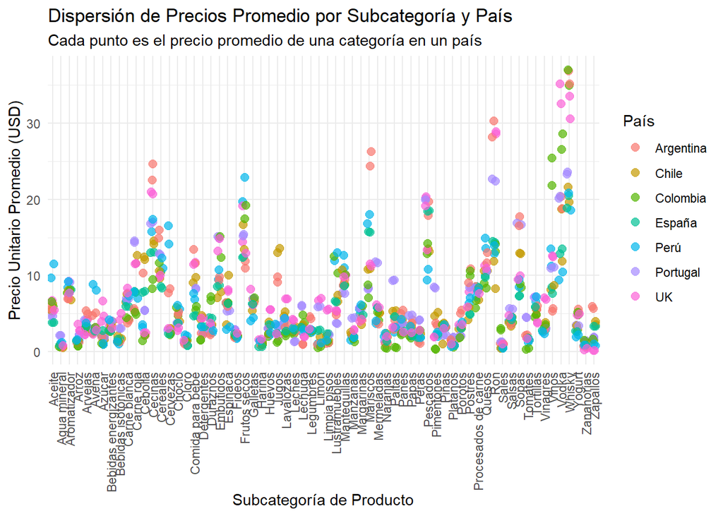

```r
#Exploración de datos

# Generamos el gráfico de dispersión
ggplot(precio_por_subcategoria, aes(x = Sub_categoria, y = Precio_Unitario_Promedio, color = Pais)) +
  geom_jitter(width = 0.25, alpha = 0.7, size = 2.5) + # Jitter para evitar solapamiento
  labs(
    title = "Dispersión de Precios Promedio por Subcategoría y País",
    subtitle = "Cada punto es el precio promedio de una categoría en un país",
    x = "Subcategoría de Producto",
    y = "Precio Unitario Promedio (USD)",
    color = "País"
  ) +
  theme_minimal() +
  theme(
    axis.text.x = element_text(angle = 90, vjust = 0.5, hjust=1) #Rotar etiquetas del eje X
  )
```

Notamos que cada subcategoria tiene cierto nivel de precio, por lo que seria interesante controlar por esa variable.

Exploramos solo por un conjunto de productos.

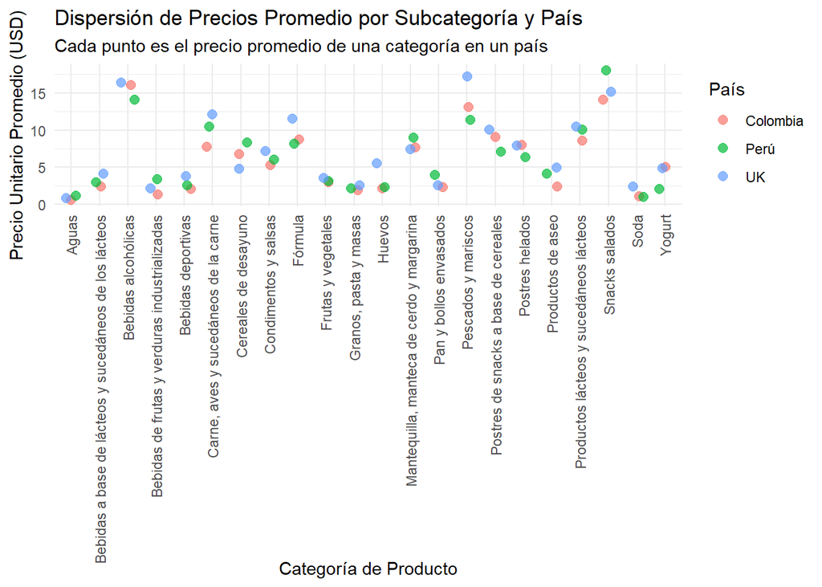

```r
#Mini filtro por algunos paises.
precio_categorias_comunes <- precio_por_categoria %>%
  filter(Pais %in% c("Perú", "Colombia", "UK"))

#Graficamos.
ggplot(precio_categorias_comunes, aes(x = Categoria, y = Precio_Unitario_Promedio, color = Pais)) +
  geom_jitter(width = 0.25, alpha = 0.7, size = 2.5) + # Jitter para evitar solapamiento
  labs(title = "Dispersión de Precios Promedio por Subcategoría y País",
    subtitle = "Cada punto es el precio promedio de una categoría en un país",
    x = "Categoría de Producto",
    y = "Precio Unitario Promedio (USD)",
    color = "País") +
  theme_minimal() +
  theme(axis.text.x = element_text(angle=90,vjust=0.5,hjust=1) # Rotar etiquetas del eje X
  )
```

El anterior grafico se visualiza bien si es que se abre hacia otra ventana.

Esto se hizo para entender una muestra, por ejemplo se ve que UK parece ser el más caro de los 3 y Colombia el más barato.

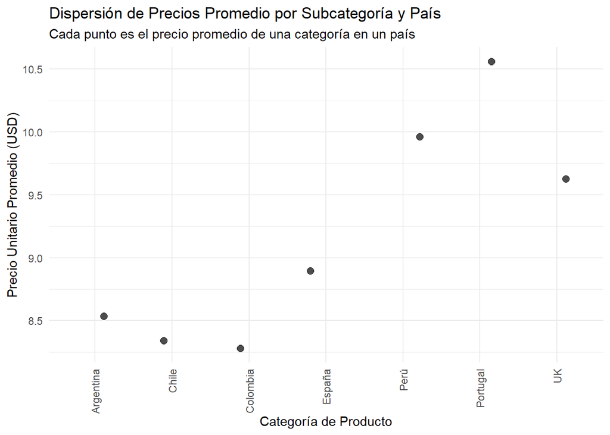

```r
#Graficamos promediando todos los productos de un pais.
ggplot(precio_por_pais, aes(x = Pais, y = Precio_Unitario_Promedio)) +
  geom_jitter(width = 0.25, alpha = 0.7, size = 2.5) + # Jitter para evitar solapamiento
  labs(title = "Dispersión de Precios Promedio por Subcategoría y País",
    subtitle = "Cada punto es el precio promedio de una categoría en un país",
    x = "Categoría de Producto",
    y = "Precio Unitario Promedio (USD)",
    color = "País") +
  theme_minimal() +
  theme(axis.text.x = element_text(angle = 90, vjust = 0.5, hjust=1) # Rotar etiquetas del eje X
  )
```

Luego de ver visualmente la distribución de variables, podriamos estudiar el ranking de paises baratos/caros, usando un ranking.Esto porque al promediar, se está sobreponderando a los productos más caros. Luego el ranking asigna un número del 1 al 7, donde 7 corresponde al país más caro.

Hacemos un ranking a nivel promedio completo de productos.

```r
# Ranking por producto y año
ranking_productos <- precio_por_subcategoria %>%
  group_by(Ano, Sub_categoria) %>%
  mutate(Rank_del_Pais = rank(Precio_Unitario_Promedio, ties.method = "first")) %>%
  ungroup()

# Ranking agregado por país
ranking_final <- ranking_productos %>%
  group_by(Pais) %>%
  summarise(RankTotal = sum(Rank_del_Pais, na.rm = TRUE)) %>%
  arrange(RankTotal)

# 4. Resultado
print(ranking_final)
```

```
## # A tibble: 7 × 2
##   Pais      RankTotal
##   <chr>         <int>
## 1 Colombia        422
## 2 España          442
## 3 Perú            521
## 4 Chile           539
## 5 Argentina       542
## 6 Portugal        644
## 7 UK              651
```

Este ranking se corresponde con la intuición y experiencia donde de forma absoluta, es más caro UK y más barato Colombia.

Luego de estudiar la base, agregamos variables que podrian explicar el modelo. Y la unimos a nuestra anterior base. Esto viene en la siguiente pregunta.

#### Pregunta 2

Usando los aprendizajes derivados de la exploración de datos, utilicen un enfoque de regresión lineal para examinar cuantitativamente qué factores determinan los distintos niveles de precios que pueden haber. En particular, consideren que nos interesa comparar niveles de precios entre países.

1. (1.0 puntos) Propongan al menos dos especificaciones alternativas para el objetivo propuesto. Justifiquen muy brevemente por qué las variables explicativas que está incluyendo en el modelo tienen sentido desde el punto de vista del problema. Justifiquen además el nivel de agregación escogido y los índices considerados en el modelo.

Primero proponemos una especificación solo con variables macro externas y haremos otra con variables de la base, como cadena por ejemplo. Esto dado que como son solo 7 países, se tiene muy poca varianza solo con las variables macro por país y para 2 años.

El nivel de agregación escogido es el precio por subcategoría dado que por ejemplo leche de chocolate o normal es indiferente y como se vio antes tienen precios similares, en un país determinado y en un tiempo determinado. Por esta razón se agregan efectos fijos por estas 3 variables.

Aranceles refleja los aranceles a la importación, esto impacta en los costos de un producto y por lo tanto en su precio final, es esperable que su signo sea positivo.

LPI es un índice de que tan buena es la logística en un país, a mejor logística menores serán los precios, por tanto debería tener signo negativo. Es esperable que a mayor GDPpc mayor sea el precio de los alimentos pues los costos suben, hay mayores sueldos, costos de producción que se cargan en el precio final.

Inflation, average consumer prices index es un indicador de la inflación en la canasta básica, es esperable que sea positivo.

Mayor UrbGrow(crecimiento urbano), lleva a menor precio pues al haber mayor competencia y acceso a mercados en las ciudades, los precios caen.

Por último, Import_PIB es el porcentaje del PIB que representan las importaciones, se tiene una mayor exposición cambiaria y también afecta que si se importa demasiado se tiene una dependencia externa alta lo que subirá los precios, luego será positivo.

```r
#Ya tenemos cargada la base de macros, y transformada en P0.
# Estimamos con efectos fijos
modelo_macro_fe <- feols(
  PrecioU_oferta_usd ~ GDPpc_miles + Arancel + UrbGrow +
    LPI + Inflacion + Import_PIB + FoodImp | Sub_categoria + Ano,
  data = data_macro
)
```

```
## NOTE: 12 observations removed because of NA values (LHS: 12).
```

```r
summary(modelo_macro_fe) #Tabla
```

```
## OLS estimation, Dep. Var.: PrecioU_oferta_usd
## Observations: 13,954
## Fixed-effects: Sub_categoria: 87,  Ano: 2
## Standard-errors: Clustered (Sub_categoria)
##              Estimate Std. Error   t value  Pr(>|t|)
## GDPpc_miles -0.012829   0.053696 -0.238925 0.8117324
## Arancel     -0.006606   0.106207 -0.062197 0.9505500
## UrbGrow      2.143261   0.708695  3.024235 0.0032856 **
## LPI          0.551981   2.032773  0.271541 0.7866260
## Inflacion   -0.000507   0.000705 -0.719553 0.4737509
## Import_PIB   0.047984   0.043532  1.102285 0.2734129
## FoodImp     -0.505912   0.342291 -1.478018 0.1430562
## ---
## Signif. codes:  0 '***' 0.001 '**' 0.01 '*' 0.05 '.' 0.1 ' ' 1
## RMSE: 14.8     Adj. R2: 0.372399
##              Within R2: 0.002053
```

```r
#Datos micro cargados y transformados en P0.

modelo_micro_fe <- feols(
  PrecioU_oferta_usd ~ MarcaPropia + Promocion + Cadena |
    Categoria + Pais + Ano,
  data = data_micro)
```

```
## The variables 'CadenaOlímpica', 'CadenaPingo Doce', 'CadenaPlaza Vea' and 'CadenaTesco' have been removed because of collinearity (see $collin.var).
```

```r
summary(modelo_micro_fe) #Tabla
```

```
## OLS estimation, Dep. Var.: PrecioU_oferta_usd
## Observations: 11,982
## Fixed-effects: Categoria: 24,  Pais: 7,  Ano: 2
## Standard-errors: Clustered (Categoria)
##                    Estimate Std. Error  t value  Pr(>|t|)
## MarcaPropia1      -1.364034    0.29895 -4.56281 0.0001384 ***
## Promocion1        -0.483553    0.28148 -1.71789 0.0992521 .
## CadenaContinente   0.485772    0.61554  0.78919 0.4380636
## CadenaÉxito        1.574495    0.47067  3.34522 0.0028069 **
## CadenaJumbo        2.891221    1.28825  2.24430 0.0347315 *
## CadenaLider        2.081338    1.21247  1.71660 0.0994912 .
## CadenaMercadona   -1.573223    0.44708 -3.51891 0.0018411 **
## CadenaMetro       -0.746065    0.79204 -0.94195 0.3560060
## CadenaSainsbury’s  0.064487    0.35550  0.18140 0.8576445
## ... 4 variables were removed because of collinearity (CadenaOlímpica, CadenaPingo Doce and 2 others [full set in $collin.var])
## ---
## Signif. codes:  0 '***' 0.001 '**' 0.01 '*' 0.05 '.' 0.1 ' ' 1
## RMSE: 6.52159     Adj. R2: 0.308441
##                 Within R2: 0.020085
```

```r
modelo_micro_fesub <- feols(
  PrecioU_oferta_usd ~ MarcaPropia + Promocion + Cadena |
    Sub_categoria + Pais + Ano,
  data = data_micro)
```

```
## The variables 'CadenaOlímpica', 'CadenaPingo Doce', 'CadenaPlaza Vea' and 'CadenaTesco' have been removed because of collinearity (see $collin.var).
```

```r
summary(modelo_micro_fesub) #Tabla
```

```
## OLS estimation, Dep. Var.: PrecioU_oferta_usd
## Observations: 11,982
## Fixed-effects: Sub_categoria: 66,  Pais: 7,  Ano: 2
## Standard-errors: Clustered (Sub_categoria)
##                    Estimate Std. Error  t value   Pr(>|t|)
## MarcaPropia1      -1.215522    0.24104 -5.04278 3.9230e-06 ***
## Promocion1        -0.622427    0.26601 -2.33990 2.2371e-02 *
## CadenaContinente   0.479987    0.58154  0.82537 4.1218e-01
## CadenaÉxito        1.801049    0.53749  3.35088 1.3454e-03 **
## CadenaJumbo        2.653555    0.87745  3.02418 3.5670e-03 **
## CadenaLider        1.824315    0.87795  2.07793 4.1670e-02 *
## CadenaMercadona   -1.359376    0.31423 -4.32604 5.3401e-05 ***
## CadenaMetro       -0.664117    0.74437 -0.89219 3.7558e-01
## CadenaSainsbury’s  0.046001    0.35667  0.12898 8.9778e-01
## ... 4 variables were removed because of collinearity (CadenaOlímpica, CadenaPingo Doce and 2 others [full set in $collin.var])
## ---
## Signif. codes:  0 '***' 0.001 '**' 0.01 '*' 0.05 '.' 0.1 ' ' 1
## RMSE: 5.94255     Adj. R2: 0.423767
##                 Within R2: 0.021128
```

Como comentario, se filtra para que no aparezcan sub_categoría, país, año porque son efectos fijos, no regresores. Por tanto, cuando Lasso muestra los regresores que seleccionó, no debe incluirlos.

2. (1.0 puntos) Sobre los dos modelos planteados en la parte anterior, apliquen algún método de selección automática de variables aprendido en clases y compare con respecto a los resultados anteriores. Deben indicar cuáles variables descartan.

```r
#Utilizamos la base macro ya procesada en p0.
data_macro_lasso <- data_macro %>%
dplyr::select(PrecioU_oferta_usd, GDPpc_miles, Arancel, UrbGrow, LPI, Inflacion, Import_PIB, FoodImp) %>%
na.omit()

#Variable dependiente
y_macro <- as.matrix(data_macro_lasso$PrecioU_oferta_usd)

#Matriz de regresores (incluye efectos fijos como dummies)
X_macro <- model.matrix(PrecioU_oferta_usd ~ GDPpc_miles + Arancel + UrbGrow + LPI + Inflacion + Import_PIB + FoodImp , data = data_macro_lasso )[, -1] # quitamos el intercepto

#Estimamos con LASSO y validación cruzada
set.seed(123) # semilla
cv_macro_lasso <- cv.glmnet(X_macro, y_macro, alpha = 1, standardize = TRUE)

#Lambda óptimo elegido por CV
cat("Lambda óptimo:", cv_macro_lasso$lambda.min, "\n")
```

```
## Lambda óptimo: 0.11701
```

```r
#Variables seleccionadas con coeficiente 0
coef_macro <- coef(cv_macro_lasso, s = "lambda.min") #Extraemos el coeficiente
selected_vars <- rownames(coef_macro)[which(coef_macro != 0)]
cat("Variables seleccionadas por LASSO:\n")
```

```
## Variables seleccionadas por LASSO:
```

```r
print(selected_vars)
```

```
## [1] "(Intercept)" "GDPpc_miles" "UrbGrow"     "Import_PIB"
```

```r
#Utilizamos la base micro ya procesada en p0.
#Variable dependiente
y_micro <- as.matrix(data_micro$PrecioU_oferta_usd)

#Matriz de regresores (incluye efectos fijos como dummies)
X_micro <- model.matrix(
  PrecioU_oferta_usd ~ MarcaPropia + Promocion + Cadena +
    factor(Sub_categoria) + factor(Pais) + factor(Ano),
  data = data_micro
)[, -1] # quitamos el intercepto

#Estimación con LASSO y validación cruzada
set.seed(123)  # semilla
cv_micro_lasso <- cv.glmnet(X_micro, y_micro, alpha = 1, standardize = TRUE)

#Lambda óptimo elegido por CV
cat("Lambda óptimo:", cv_micro_lasso$lambda.min, "\n")
```

```
## Lambda óptimo: 0.0012156
```

```r
##Variables seleccionadas con coeficiente 0
coef_micro <- coef(cv_micro_lasso, s = "lambda.min")
selected_vars_micro <- rownames(coef_micro)[which(coef_micro != 0)]
#limpiamos interceptos de subcategoria, Pais y Ano
selected_vars_micro_clean <- selected_vars_micro[!grepl("Intercept|Sub_categoria|Pais|Ano", selected_vars_micro)]
cat("Variables seleccionadas por LASSO (solo micro, sin FE):\n")
```

```
## Variables seleccionadas por LASSO (solo micro, sin FE):
```

```r
print(selected_vars_micro_clean)
```

```
##  [1] "MarcaPropia1"      "Promocion1"        "CadenaContinente"
##  [4] "CadenaÉxito"       "CadenaJumbo"       "CadenaLider"
##  [7] "CadenaMercadona"   "CadenaMetro"       "CadenaOlímpica"
## [10] "CadenaPingo Doce"  "CadenaPlaza Vea"   "CadenaSainsbury’s"
## [13] "CadenaTesco"
```

#### Pregunta 3

(1.0 puntos) Usen al menos dos de los modelos de aprendizaje de máquinas que vimos en clases (MARS, kNN, regression tree o random forest) para generar un pronóstico de precios para un país, año, mes y produto dado. Comparen la capacidad de estos modelos con respecto a los de regresión lineal utilizando métricas de desempeño (MSE, RMSE o MAE). Discutan brevemente sus resultados y el modelo que recomendaría usar.

```r
#Filtramos data macro
set.seed(5162) #Semilla
data_ag <- data_macro %>%
  select(Ano, Mes, Pais, Sub_categoria,PrecioU_oferta_usd,GDPpc_miles,Arancel,UrbGrow,Import_PIB) %>%
  mutate(across(c(Pais, Sub_categoria), as.factor)) %>%
  filter(is.finite(PrecioU_oferta_usd))


#Utilizamos las variables significativas del modelo macro: Arancel,UrbGrow,Import_PIB y GDPpc_miles

#División de datos 80 -20
idx <- createDataPartition(data_ag$Sub_categoria, p = 0.8, list = FALSE)
train_df <- data_ag[idx, ]
test_df  <- data_ag[-idx, ]
fml <- PrecioU_oferta_usd ~ .

#Entrenamiento de modelos
ctrl <- trainControl(method = "cv", number = 10, savePredictions = "final")
modelo_lm   <- train(fml, data = train_df, method = "lm", trControl = ctrl)
modelo_mars <- train(fml, data = train_df, method = "earth", trControl = ctrl, tuneGrid = expand.grid(degree=1, nprune=5:12))
modelo_rf   <- train(fml, data = train_df, method = "rf", trControl = ctrl, tuneGrid = expand.grid(mtry = 2:4), ntree = 100)

#Comparación de métricas de desempeño ---
model_list <- list(LM = modelo_lm, MARS = modelo_mars, RF = modelo_rf)
results <- resamples(model_list)
summary(results)
```

```
##
## Call:
## summary.resamples(object = results)
##
## Models: LM, MARS, RF
## Number of resamples: 10
##
## MAE
##        Min. 1st Qu. Median   Mean 3rd Qu.   Max. NA's
## LM   4.4608  4.7452 4.8760 4.9227  5.0088 5.4890    0
## MARS 5.7575  6.0198 6.2987 6.2761  6.5167 6.8230    0
## RF   4.6200  4.8813 4.9944 5.0530  5.2315 5.7123    0
##
## RMSE
##        Min. 1st Qu. Median   Mean 3rd Qu.   Max. NA's
## LM   9.8130  11.156 13.063 14.811  17.157 24.277    0
## MARS 9.6716  11.277 15.264 15.314  17.226 23.931    0
## RF   8.0471  10.024 12.917 14.205  14.119 25.389    0
##
## Rsquared
##         Min. 1st Qu.  Median    Mean 3rd Qu.    Max. NA's
## LM   0.18706 0.34937 0.38162 0.39084 0.45371 0.54890    0
## MARS 0.16162 0.31504 0.36477 0.34546 0.40061 0.44691    0
## RF   0.16397 0.34724 0.52091 0.45904 0.56714 0.63548    0
```

[figure not shown]

```r
#Creación de Boxplots de Errores
# a) Realizamos las predicciones en el set de prueba
pred.lm   <- predict(modelo_lm,   newdata = test_df)
pred.mars <- predict(modelo_mars, newdata = test_df)
pred.rf   <- predict(modelo_rf,   newdata = test_df)

#Calculamos los errores de predicción (valor real - predicción)
error.df <- data.frame(
  LM   = test_df$PrecioU_oferta_usd - pred.lm,
  MARS = test_df$PrecioU_oferta_usd - pred.mars,
  RF   = test_df$PrecioU_oferta_usd - pred.rf
)

#Generamos los boxplots
# Primero, configuramos la ventana gráfica para mostrar dos gráficos juntos
par(mfrow = c(1, 2))
boxplot(error.df, main = "Errores de Predicción") #G1 Errores de predicción
boxplot(abs(error.df), main = "Errores Absolutos de Predicción") #G2 Errores absolutos (para ver la magnitud del error)
```

```r
par(mfrow = c(1, 1)) # Reseteamos la configuración de la ventana gráfica
```

```r
# Predicción para un producto puntual y comparación.
new_caso <- expand.grid(
  Pais = factor("Chile", levels = levels(train_df$Pais)),
  Sub_categoria = factor("Panes", levels = levels(train_df$Sub_categoria)),
  Ano  = 2022, # Aqui agregamos los valores que si conocemos para ese periodo.
  Mes  = 2,
  Arancel = 1.0,
  UrbGrow = 0.6,
  Import_PIB = 39.6,
  GDPpc_miles = 15.405
)

predicciones <- sapply(model_list, function(modelo) predict(modelo, newdata = new_caso))

obs <- data_ag %>%
  filter(Ano==2022, Mes==2, Pais=="Chile", Sub_categoria=="Panes") %>%
  slice(1) %>%
  pull(PrecioU_oferta_usd) # Extraemos precio unitario final en usd.
pred_puntual <- data.frame(
  Modelo = names(predicciones),
  Prediccion = predicciones,
  Observado = obs
)
print(pred_puntual) # Comparamos
```

```
##      Modelo Prediccion Observado
## LM.1   LM.1     3.1409    5.1438
## MARS   MARS     5.9940    5.1438
## RF.1   RF.1     4.8060    5.1438
```

La regresión lineal y Random Forest rindieron de forma muy similar en validación superando a MARS en la predicción puntual Chile–Panes–2022-02, RF quedó prácticamente en el valor observado 4.8), MARS sobreestimó (5.99) y LM subestimó (3.14), por lo que, considerando precisión puntual y posibles no linealidades, es recomendable usar random forest.

#### Pregunta 4

En vez de pedir que generen una canasta para cada mes año y pais, sugeriría que eligan 3 canasta con al menos 5 productos de su elección y pronostiquen el precio para todos los paises en una fecha en particular. Asi tenemos más variación en las respuestas y dificultamos la copia.

1. (1.0 puntos) Elaboren tres canastas de abarrotes con al menos cinco productos de sus preferencias para todos los países en alguna fecha cualquiera. Pronostiquen su precio corregido por moneda (USD) incluyendo variables explicativas relevantes. Comparen el precio de Chile con respecto al resto de países.

```r
#Definimos las canastas de abarrotes que utilizaremos
canasta_basica <- c("Arroz", "Fideos", "Aceite", "Panes", "Huevos", "Leches")
canasta_carnes_verduras <- c("Carne roja", "Carne blanca", "Pescados", "Tomates", "Lechuga", "Papas")
canasta_aseo_hogar <- c("Detergentes", "Cloro", "Lavalozas", "Limpia pisos", "Aromatizador")

# Creamos un dataframe con la definición de las canastas, esto para que luego se unan a los atributos correspondientes.
definicion_canastas <- data.frame(
  Sub_categoria = c(canasta_basica, canasta_carnes_verduras,canasta_aseo_hogar),
  Canasta = rep(c("Básica", "Carnes y Verduras", "Aseo del Hogar"),
  times = c(length(canasta_basica), length(canasta_carnes_verduras),
            length(canasta_aseo_hogar)))
)

# Creamos los escenarios de predicción, como vamos a predecir los precios para Marzo de 2022 en todos los países, entonces necesitamos todos los valores macros correspondientes a ese periodo, y lo agregamos mediante atributos referenciados para cada pais.
escenario_prediccion <- expand.grid(
  Sub_categoria = definicion_canastas$Sub_categoria,
  Pais          = levels(train_df$Pais),
  Ano           = 2022,
  Mes           = 3) %>%
  mutate(
    GDPpc_miles = case_when(
      Pais == "Argentina" ~ 13.935,
      Pais == "Chile"     ~ 15.405,
      Pais == "Colombia"  ~ 6.680,
      Pais == "Perú"      ~ 7.350,
      Pais == "Portugal"  ~ 24.620,
      Pais == "España"    ~ 30.270,
      Pais == "UK"        ~ 46.063
    ),
    Arancel = case_when(
      Pais == "Argentina" ~ 11.9,
      Pais == "Chile"     ~ 1.0,
      Pais == "Colombia"  ~ 3.5,
      Pais == "Perú"      ~ 1.1,
      Pais == "Portugal"  ~ 1.9,
      Pais == "España"    ~ 1.9,
      Pais == "UK"        ~ 1.1
    ),
    UrbGrow = case_when(
      Pais == "Argentina" ~ 0.3,
      Pais == "Chile"     ~ 0.6,
      Pais == "Colombia"  ~ 1.4,
      Pais == "Perú"      ~ 1.4,
      Pais == "Portugal"  ~ 1.5,
      Pais == "España"    ~ 1.0,
      Pais == "UK"        ~ 1.2
    ),
    Import_PIB = case_when(
      Pais == "Argentina" ~ 15.3,
      Pais == "Chile"     ~ 39.6,
      Pais == "Colombia"  ~ 27.9,
      Pais == "Perú"      ~ 28.5,
      Pais == "Portugal"  ~ 51.9,
      Pais == "España"    ~ 38.9,
      Pais == "UK"        ~ 35.3
    )
  )


# Pronosticar precios usando Random Forest
escenario_prediccion$Precio_Predicho_USD <- predict(model_list$RF, newdata = escenario_prediccion)

# Calcular el costo total de cada canasta por país
costo_final_canastas <- escenario_prediccion %>%
  left_join(definicion_canastas, by = "Sub_categoria") %>%
  group_by(Pais, Canasta) %>% # En este caso debemos sumar el precio de cada elemento para crear el costo de la canasta.
  summarise(Costo_Total_USD = sum(Precio_Predicho_USD), .groups = 'drop')

# Vemos los resultados y comparar
cat("Pronóstico del Costo Total por Canasta y País (en USD):\n")
```

```
## Pronóstico del Costo Total por Canasta y País (en USD):
```

```r
print(costo_final_canastas)
```

```
## # A tibble: 21 × 3
##    Pais      Canasta           Costo_Total_USD
##    <fct>     <chr>                       <dbl>
##  1 Argentina Aseo del Hogar               21.3
##  2 Argentina Básica                       27.7
##  3 Argentina Carnes y Verduras            43.1
##  4 Chile     Aseo del Hogar               24.0
##  5 Chile     Básica                       28.6
##  6 Chile     Carnes y Verduras            46.2
##  7 Colombia  Aseo del Hogar               22.0
##  8 Colombia  Básica                       26.6
##  9 Colombia  Carnes y Verduras            44.1
## 10 España    Aseo del Hogar               22.5
## # ℹ 11 more rows
```

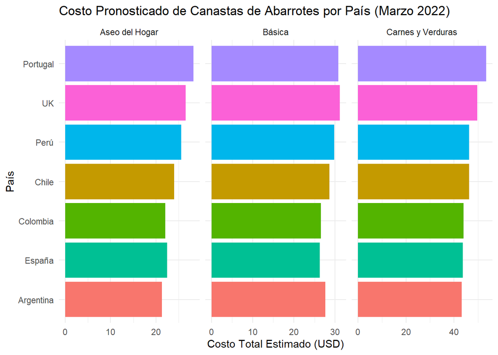

```r
# Graficamos para comparar.
ggplot(costo_final_canastas, aes(x = reorder(Pais, Costo_Total_USD), y = Costo_Total_USD, fill = Pais)) +
  geom_bar(stat = "identity") +
  facet_wrap(~ Canasta, scales = "free_x") +
  coord_flip() +
  labs(
    title = "Costo Pronosticado de Canastas de Abarrotes por País (Marzo 2022)",
    x = "País",
    y = "Costo Total Estimado (USD)"
  ) +
  theme_minimal() +
  theme(legend.position = "none")
```

```r
# Calcular el costo OBSERVADO de cada canasta.
costo_observado_ajustado <- data_ag %>%
  filter(Ano == 2022, Mes %in% c(2, 3)) %>% # Tomamos ambos meses porque para el caso de chile, tiene sus productos en febrero.
  group_by(Pais, Sub_categoria) %>%
  # Promediamos el precio de cada producto en los dos meses
  summarise(Precio_Promedio_Obs = mean(PrecioU_oferta_usd, na.rm = TRUE), .groups = 'drop') %>%
  # sumamos los precios promedio para obtener el costo de la canasta
  right_join(definicion_canastas, by = "Sub_categoria") %>%
  group_by(Pais, Canasta) %>%
  summarise(Costo_Observado_USD = sum(Precio_Promedio_Obs, na.rm = TRUE), .groups = 'drop')

#Unimos la tabla de pronósticos con la de costos observados.
tabla_comparativa_ajustada <- costo_final_canastas %>%
  left_join(costo_observado_ajustado, by = c("Pais", "Canasta")) %>%
  rename(Costo_Pronosticado_USD = Costo_Total_USD)

#Printeamos
cat("Tabla Comparativa: Costo Pronosticado vs. Costo Observado (Promedio Feb-Mar 2022):\n")
```

```
## Tabla Comparativa: Costo Pronosticado vs. Costo Observado (Promedio Feb-Mar 2022):
```

```r
print(tabla_comparativa_ajustada)
```

```
## # A tibble: 21 × 4
##    Pais      Canasta           Costo_Pronosticado_USD Costo_Observado_USD
##    <fct>     <chr>                              <dbl>               <dbl>
##  1 Argentina Aseo del Hogar                      21.3                14.3
##  2 Argentina Básica                              27.7                16.2
##  3 Argentina Carnes y Verduras                   43.1                33.7
##  4 Chile     Aseo del Hogar                      24.0                20.7
##  5 Chile     Básica                              28.6                19.8
##  6 Chile     Carnes y Verduras                   46.2                42.3
##  7 Colombia  Aseo del Hogar                      22.0                14.8
##  8 Colombia  Básica                              26.6                16.6
##  9 Colombia  Carnes y Verduras                   44.1                30.9
## 10 España    Aseo del Hogar                      22.5                16.6
## # ℹ 11 more rows
```

En USD de mercado para marzo de 2022, Chile se ubica en la mitad alta del ranking: sus costos pronosticados por canasta son mayores que los de Argentina y Colombia y menores que los de UK y Portugal, quedando por encima de España en las tres canastas.

2. (0.5 puntos) Utilicen las mismas canastas de abarrotes y pronostiquen su precio corregido por moneda (USD) y por paridad de poder adquisitivo (ppa) incluyendo variables explicativas relevantes. Comparen el precio de Chile con respecto al resto de países. Expliquen brevemente en qué se diferencia esta métrica en comparación a solo corregir por moneda.

Tendremos que convertir la base con respecto a ppa, ya que ya corregimos por moneda. La base ppa fue procesada en p0 al igual que tipo de cambio.

```r
set.seed(5162) #Semilla

# Preparar la base de datos para corregir por ppa y dolar.
base_int <- data_macro %>%
  left_join(Tipo_Cambio, by = c("Pais", "Ano", "Mes")) %>%
  left_join(ppa, by = c("Pais", "Ano")) %>%
  mutate(Precio_Int = PrecioU_oferta_usd / (TipoCambio * Factor_PPA)) %>%
  filter(is.finite(Precio_Int)) %>%
  select(Ano, Mes, Pais,Sub_categoria,GDPpc_miles,Arancel,UrbGrow,Import_PIB, Precio_Int) %>%
  mutate(across(c(Pais, Sub_categoria), as.factor))

# Dividir datos y entrenar nuevamente pero con las correciones por ppa y dolar.
idx   <- createDataPartition(base_int$Sub_categoria, p = 0.8, list = FALSE)
train <- base_int[idx, ]
fml   <- Precio_Int ~ .

modelo_rf_int <- train(
  fml, data = train, method = "rf",
  trControl = trainControl("cv", number = 5), # 5 folds para mayor rapidez
  tuneGrid = expand.grid(mtry = 2:4),
  ntree = 100 # Es el numero de arboles con los cuales el codigo no se demoraba +1 hora.
)
```

```r
#Definimos la misma canasta que en p4a y utilizamos el mismo escenario de predicción.
canasta_basica <- c("Arroz", "Fideos", "Aceite", "Panes", "Huevos", "Leches")
canasta_carnes_verduras <- c("Carne roja", "Carne blanca", "Pescados", "Tomates", "Lechuga", "Papas")
canasta_aseo_hogar <- c("Detergentes", "Cloro", "Lavalozas", "Limpia pisos", "Aromatizador")

#definición de las canastas, esto para que luego se unan a los atributos correspondientes.
definicion_canastas <- data.frame(
  Sub_categoria = c(canasta_basica, canasta_carnes_verduras,canasta_aseo_hogar),
  Canasta = rep(c("Básica", "Carnes y Verduras", "Aseo del Hogar"),
  times = c(length(canasta_basica), length(canasta_carnes_verduras),
            length(canasta_aseo_hogar))))

escenario_prediccion <- expand.grid(
  Sub_categoria = definicion_canastas$Sub_categoria,
  Pais          = levels(train$Pais),
  Ano           = 2022,
  Mes           = 3) %>%
  mutate(
    GDPpc_miles = case_when(
      Pais == "Argentina" ~ 13.935,
      Pais == "Chile"     ~ 15.405,
      Pais == "Colombia"  ~ 6.680,
      Pais == "Perú"      ~ 7.350,
      Pais == "Portugal"  ~ 24.620,
      Pais == "España"    ~ 30.270,
      Pais == "UK"        ~ 46.063
    ),
    Arancel = case_when(
      Pais == "Argentina" ~ 11.9,
      Pais == "Chile"     ~ 1.0,
      Pais == "Colombia"  ~ 3.5,
      Pais == "Perú"      ~ 1.1,
      Pais == "Portugal"  ~ 1.9,
      Pais == "España"    ~ 1.9,
      Pais == "UK"        ~ 1.1
    ),
    UrbGrow = case_when(
      Pais == "Argentina" ~ 0.3,
      Pais == "Chile"     ~ 0.6,
      Pais == "Colombia"  ~ 1.4,
      Pais == "Perú"      ~ 1.4,
      Pais == "Portugal"  ~ 1.5,
      Pais == "España"    ~ 1.0,
      Pais == "UK"        ~ 1.2
    ),
    Import_PIB = case_when(
      Pais == "Argentina" ~ 15.3,
      Pais == "Chile"     ~ 39.6,
      Pais == "Colombia"  ~ 27.9,
      Pais == "Perú"      ~ 28.5,
      Pais == "Portugal"  ~ 51.9,
      Pais == "España"    ~ 38.9,
      Pais == "UK"        ~ 35.3
    )
  )
```

```r
#Pronosticar, calcular costos y comparar con lo observado
tabla_comparativa_final <- escenario_prediccion %>%
  #Pronosticar precios
  mutate(Precio_Predicho_Int = predict(modelo_rf_int, newdata = .)) %>%
  left_join(definicion_canastas, by = "Sub_categoria") %>%
  #Calcular costo pronosticado de la canasta
  group_by(Pais, Canasta) %>%
  summarise(Costo_Pronosticado_Int = sum(Precio_Predicho_Int), .groups = "drop") %>%
  #Unir con el costo observado
  left_join(
    base_int %>%
    filter(Ano == 2022, Mes %in% c(2, 3)) %>%
    group_by(Pais, Sub_categoria) %>%
    summarise(Precio_Promedio_Int = mean(Precio_Int, na.rm = TRUE),.groups ="drop") %>%
    inner_join(definicion_canastas, by = "Sub_categoria") %>%
    group_by(Pais, Canasta) %>%
    summarise(Costo_Observado_Int = sum(Precio_Promedio_Int, na.rm = TRUE),.groups = "drop"),by = c("Pais", "Canasta")) %>%
  #Añadir la comparación con Chile
    group_by(Canasta) %>%
    mutate(Ratio_vs_Chile = round(Costo_Pronosticado_Int / Costo_Pronosticado_Int[Pais == "Chile"], 2)) %>%
  ungroup() %>%
  arrange(Canasta, desc(Costo_Pronosticado_Int))

#Printeamos
kable(tabla_comparativa_final,caption = "Comparación de Costos de Canastas (Pronosticado vs. Observado) en Int$",digits = 2)
```

Comparación de Costos de Canastas (Pronosticado vs. Observado) en Int$

| Pais | Canasta | Costo_Pronosticado_Int | Costo_Observado_Int | Ratio_vs_Chile |
| --- | --- | --- | --- | --- |
| Perú | Aseo del Hogar | 65.92 | 44.97 | 1.31 |
| Colombia | Aseo del Hogar | 64.62 | 40.43 | 1.29 |
| Portugal | Aseo del Hogar | 54.12 | 32.71 | 1.08 |
| Chile | Aseo del Hogar | 50.24 | 37.49 | 1.00 |
| Argentina | Aseo del Hogar | 44.93 | 25.82 | 0.89 |
| UK | Aseo del Hogar | 39.22 | 30.86 | 0.78 |
| España | Aseo del Hogar | 38.15 | 26.16 | 0.76 |
| Colombia | Básica | 74.51 | 45.41 | 1.36 |
| Perú | Básica | 69.84 | 54.14 | 1.28 |
| Portugal | Básica | 56.18 | 30.16 | 1.03 |
| Chile | Básica | 54.62 | 35.89 | 1.00 |
| Argentina | Básica | 53.83 | 29.27 | 0.99 |
| España | Básica | 44.35 | 25.90 | 0.81 |
| UK | Básica | 42.94 | 28.38 | 0.79 |
| Colombia | Carnes y Verduras | 114.50 | 84.26 | 1.34 |
| Perú | Carnes y Verduras | 106.36 | 73.74 | 1.25 |
| Portugal | Carnes y Verduras | 93.45 | 95.84 | 1.10 |
| Chile | Carnes y Verduras | 85.32 | 76.62 | 1.00 |
| Argentina | Carnes y Verduras | 76.39 | 60.83 | 0.90 |
| España | Carnes y Verduras | 69.27 | 61.25 | 0.81 |
| UK | Carnes y Verduras | 63.75 | 51.48 | 0.75 |

En Int$, el orden relativo se invierte respecto de USD: con Chile como base (=1,00), Perú y Colombia resultan más caros en Aseo del Hogar y en la canasta Básica, y también superan a Chile en Carnes y Verduras, mientras que España y UK quedan por debajo y Portugal se mantiene cercano o levemente superior. Esto ocurre porque corregir solo por moneda convierte a USD al tipo de cambio de mercado (niveles nominales), mientras que el ajuste por PPA reescala por el nivel de precios interno para que una misma canasta represente igual poder de compra, entregando una comparación real que puede cambiar el ranking observado en USD.

## Resumen

(0.5 puntos) Resuman ejecutivamente sus resultados y provean un resumen conciso de los aprendizajes y sugerencias relevantes.

```r
#Summary
```

P0

En esta pregunta se prepararon los datos, para esto primero se cargó una base con el tipo de cambio en dólares para pasar todo a una misma moneda. Además se agregó una base con 7 variables macro que posteriormente se usarán como variables explicativas. Posteriormente se transforma la base para usar solo sub categoría ya que es representativo de los productos y es lo que realmente interesa. Además de definir un precio que es igual al de oferta cuando hay oferta y si no es el precio normal. Luego de esto se normalizaron los precios por el volumen y se eliminaron productos que quedaron con precios erróneos: especias entre otros. Finalmente se aseguró el hecho de que estén las mismas subcategorías en todos los países. Luego de todo esto se agregó una base con los PPA que serán usados en preguntas posteriores.

P1

P2

Luego se propone una especificación con variables propias de la base entregada donde dio que era significativo promoción con signo negativo pues cuando hay promoción bajan los precios, marca propia también con signo negativo pues en general las marcas propias tienen precios menores y dieron algunas cadenas significativas y con el signo esperado. Por ejemplo Jumbo dio positivo pues en general tiene mayores precios y Mercadonna negativo pues es una cadena conocida por sus bajos precios.

Así mismo en el caso de MarcaPropia es negativo pues en general las marcas propias tienen productos de precios más bajos y promoción también es negativo pues baja los precios.

P3. En esta parte del codigo se arma el set con variables de tiempo, país, subcategoría y macro, se divide en entrenamiento/prueba y se entrena regresión lineal, MARS y Random Forest con validación cruzada para comparar RMSE/MAE/R². Luego se predice en el set de prueba para evaluar sesgo y magnitud del error con boxplots y, por último, se genera una predicción puntual para contrastar cada modelo con el valor observado y elegir el más preciso.

p4 a) El código arma tres canastas, predice precios unitarios en USD para mar-2022 con Random Forest incorporando variables macro (PIB per cápita, arancel, urbanización, importaciones), y suma por país para comparar el costo total. Luego contrasta esos costos pronosticados con los costos observados para evaluar sesgo.

2. En esta pregunta se reentrenó y aplicó un modelo para precios en dólares internacionales (Int$), calculados dividiendo el precio en USD por el factor PPP, lo que elimina diferencias de nivel de precios entre países; así, la comparación refleja poder de compra relativo y no solo tipo de cambio de mercado

Podemos observa que en dólares internacionales (Int$), el ranking se reordena frente a la comparación en USD: tomando a Chile como referencia (1,00), en la canasta de Aseo del Hogar Perú (1,31) y Colombia (1,29) se ubican por encima de Chile, mientras que Portugal (1,08) queda levemente arriba y España (0,76), UK ≈0,78) y Argentina (0,89) aparecen por debajo. En la canasta Básica, Colombia (1,36) y Perú (1,28) también superan a Chile, Portugal queda cercano (1,03) y España (0,81), UK (0,79) y Argentina (0,99) se sitúan por debajo. Finalmente, en Carnes y Verduras, Colombia (1,34) y Perú (1,25) vuelven a estar por encima, Portugal queda prácticamente igual (1,10) y España (0,81), UK (0,75) y Argentina (0,90) se ubican por debajo. Esta reordenación del ranking se entiende por el ajuste de paridad de poder adquisitivo, que estandariza los niveles de precios internos de cada economía y permite comparar poder de compra real entre países, corrigiendo sesgos de mirar solo el tipo de cambio de mercado.

## Anexos

Documenta acá cualquier otro adicional que consideres útil tener de referencia.

## Roles

Todos los participantes del grupo de trabajo declaran que su participación queda bien reflejada en la siguiente tabla.

**Tabla N+1:** Roles de los Participantes en el trabajo

integrantes

P1

P2

P3

P4

Resumen

Lamich

interpretación

código e interpretación

Interpretación

codigo e interpretación

interpretación

Muñoz

codigo

codigo

Interpretación

Venegas

código

códigO

código

código

Asimismo, los participantes del grupo de trabajo declaran que el uso de herramientas de inteligencia artificial (IA) queda bien reflejada en la siguiente tabla.

**Tabla N+2:** Rol de la IA en el trabajo

preguntas

uso

herramienta

P1

Ayudar a idear y generar graficos

Chat GPT-5

P2

Chat GPT-5

P3

Encontrar errores en el codigo

Chat GPT-5

P4

Encontrar errores en el codigo y ayuda a optimizar la comparativa de pronosticos y observados

Chat GPT-5

Resumen